# Home

Suhita

20 December 2018

# Overview and motivation

Most of the classification algorithms deal with datasets which have a set of input features and only *one* output class. However, in reality the problem might be different from a typical binary or multiclass classification. A single text document often has multiple semantic aspects. A single news article related to politics may have aspects related to trade, technology and defense. Therefore, often a document needs to be tagged to multiple labels/categories, instead of a single category. An introduction of enormous amount of documents belonging to multiple categories in the legal domain, makes it an attractive area for employing automated solutions.  
In this project we explore a public multi labelled legal text dataset that has been manually annotated over a decade. It contains laws related to the European Union, including treaties, legislation, case-law and legislative proposals, in 22 different languages. This is popularly known as the **EUR-Lex** dataset containing about twenty thousand documents, around seven thousand labels and in several European languages. A skewed distribution of multiple labels per document, along with existence of the same data in multiple languages, makes this dataset an interesting proposition. Few publications have used an older version of the dataset which had around four thousand labels. The ones that have used this have reported relatively poor values in the range of 50% (which may be fair, given the high number of labels). To the best of our knowledge there has been no publications for the new dataset having around 7000 labels.

> **Multilable v/s Multiclass classification**  
> In multi-label classification, each instance in the training set is associated with a set of labels, instead of a single lable, and the task is to predict the *label-sets* of unseen instances, instead of a single label. There is a difference between *multi-class classification* and *multi-label classification*. In multi-class problem the classes or labels are mutually-exclusive, i.e. it makes the assumption that each instance can be assigned to only one label. E.g - an animal can be either a dog or a cat but not both. But in multi-label problem multiple labels may be assigned to an instance. E.g - a movie can belong to a comedy genre as well a detective genre.

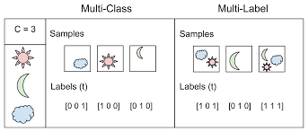

Multilable v/s Multiclass classification

# Project objectives

In this project we first perform a statistical exploratory analysis of the dataset. Secondly, we experiment the performance of various state-of-the-art classifiers on this dataset. For a better understanding of this classification task, we study the evaluation measures for the multilabel scenario. In the process, we try to answer the following research questions:

- How well the classifiers perform over Eur-Lex dataset for two languages (English and Deutsch).
- How the classifiers’ performance changes with different features- one with term frequency–inverse document frequency(tf-idf), another with term incidence.
- Which flavour of multilabel classifiers perform best among all.
- How the classifiers’ performance changes when the number of labels is reduced

# Name of dataset:

European Union law documents (EUR-Lex). The [data](https://ec.europa.eu/jrc/en/language-technologies/jrc-eurovoc-indexer#Download%20JEX) is located inside the software distributed by European Union.

# R packages

The following packages must be installed in R-Studio:  
- textstem  
- stringi  
- dplyr - data.table - tm - textclean - XML - RWeka - tidyr - parallel - mldr - utiml - ggplot2 - RColorBrewer - udpipe - xgboost - randomForest - matrixStats